# STAT 361 - RECITATION 5

### İrem Tanrıverdi, iremt@metu.edu.tr

### Date: 07.04.2022

# Topic : Monte Carlo Integration

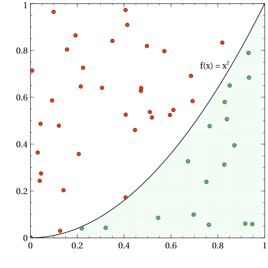

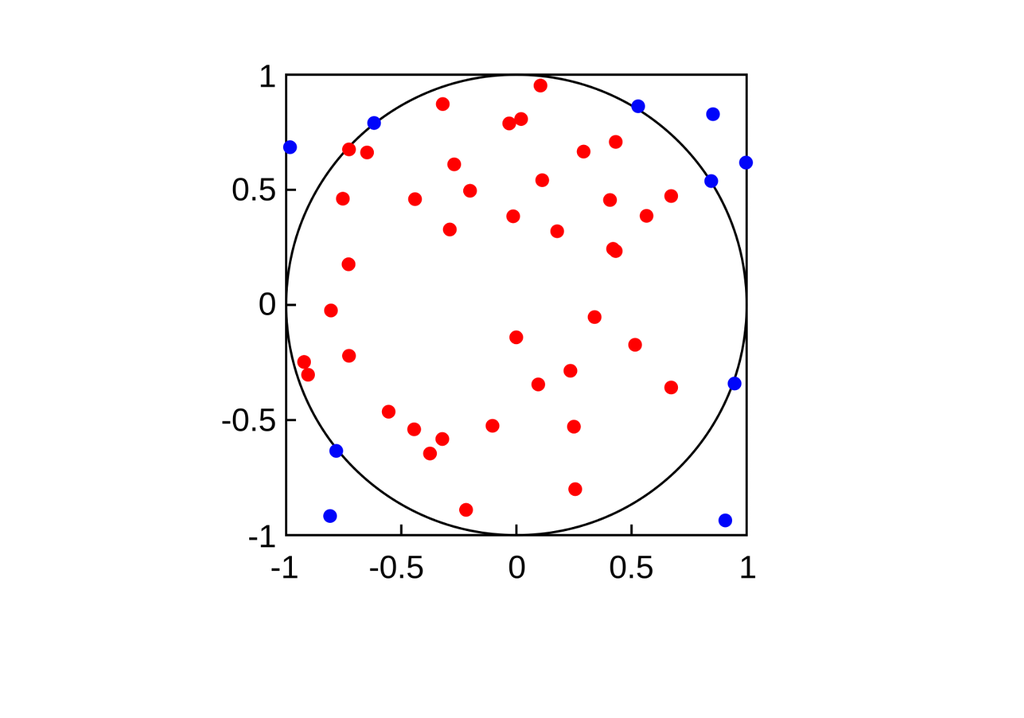

- A(square) =4
- points inside the circle = 40
- total number of points = 50
- A(circle) = 4*(40/50) = 3.2 ~= $\pi$

Monte Carlo methods are numerical techniques which rely on random sampling to approximate their results. Monte Carlo integration applies this process to the numerical estimation of integrals. Monte Carlo methods are a particularly attractive choice for the multidimensional integration problems common in computer graphics.

### Basics:

Basic idea becomes clear from the “dartboard method” of integrating the area of an irregular domain:

Choose points randomly within the rectangular box

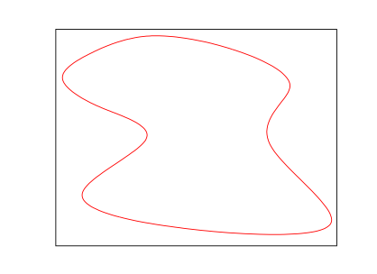

p(hit inside area) = $\frac{\text{number of hits inside area}}{\text{number of hits inside the box}}$

**Please visit this page to understand basics of Monte Carlo Integration ->** https://www.youtube.com/watch?v=8276ZswRw7M

## The Monte Carlo Estimator

It is the Basic Estimator. Monte Carlo integration uses random sampling of a function to numerically compute an estimate of its integral. Suppose that we want to integrate the one-dimensional function f (x) from a to b:

$$ \theta= \int_a^b f(x) $$

We can approximate this integral by averaging samples of the function f at uniform random points within the interval. Given a set of N uniform random variables Xi ∈ [a,b) with a corresponding PDF of $\frac{1}{m}$, the Monte Carlo estimator for computing $\theta$ is

$$ \hat \theta = g_m(\bar x) = \frac{1}{m} \sum_{i=1}^m g(x_i) $$

converges to E[g(X)] = $\theta$ with probability 1, by Strong Law of Large Numbers (SLLN).

**More simply:**

Monte Carlo integration relies on large clusters of numbers, which implies that a sample mean for a large random sample will tend to be close to the predicted value of the distance being sampled.

Suppose f(x) is any function that has an integrate on the closed interval [a,b], then the integral $\int_a^bf\left(x\right)\ dx$ gives the area of the region is bounded by (a,b).

Then,

Let $u_1,u_2, u_3,...,u_n$ be independent uniform random variables on the interval [a,b] then from the uniform distribution:

$f\left(u\right)\ =\ \frac{1}{b-a}$ so that $E\left[f\left(u\right)\right]\ =\ \int_a^bf\left(u\right)\cdot\frac{1}{b-a}du$

This defines the original integral $\int_a^bf\left(u\right)\ du$ which can be approximated by multiplying the a sample mean $f\left(u\right)$ by $\left(b-a\right)$.

### Strong law of large numbers:

Let X be a real-valued random variable, and let $X_1, X_2, X_3, …$ be an infinite sequence of independent and identically distributed copies of X. Let $\bar Xn=\frac{1}{n}(𝑋_1+⋯+𝑋_n)$ be the empirical averages of this sequence. Suppose that the first moment E|X| of X is finite. Then $\bar Xn$ converges almost surely to E(X), thus

$$ 𝑃(lim_{n-> \infty}\bar Xn=𝐸(𝑋))=1. $$

The simple Monte Carlo estimator of $\int_0^1 g(x)dx$ is $g_m(\bar x)$.

To summarize, the simple Monte Carlo estimator of the integral $\theta= \int_a^b g(x)dx$ is computed as follows;

1. Generate $𝑋_1,...,𝑋_m$ i.i.d. from Uniform(a,b).
2. Compute $\bar g(x)= \frac{1}{m} g(x_1)$
3. $\hat \theta = (b-a)\bar{g(x)}$

The generic problem: Evaluate

$$ \int_x g(x)f(x)dx=E_f[g(x)] $$

The Convergence;

$$ \bar{g_m(X)} = \frac{1}{m} \sum_{i=1}^m g(x_i)\ -> \int_x g(x)f(x)dx = E_f[g(x)] $$

is valid by Strong Law of Large Numbers.

## Advantages of Monte Carlo integration

1. It converges at any dimension, regardless of the smoothness of the integrand. This makes it particularly useful in graphics, where we often need to calculate multi-dimensional integrals of discontinuous functions.
1. Monte Carlo integration is simple. Only two basic operations are required, namely sampling and point evaluation.
1. It is general. It is based on random sampling.

### In R to solve integral, we use "integrate()" function.

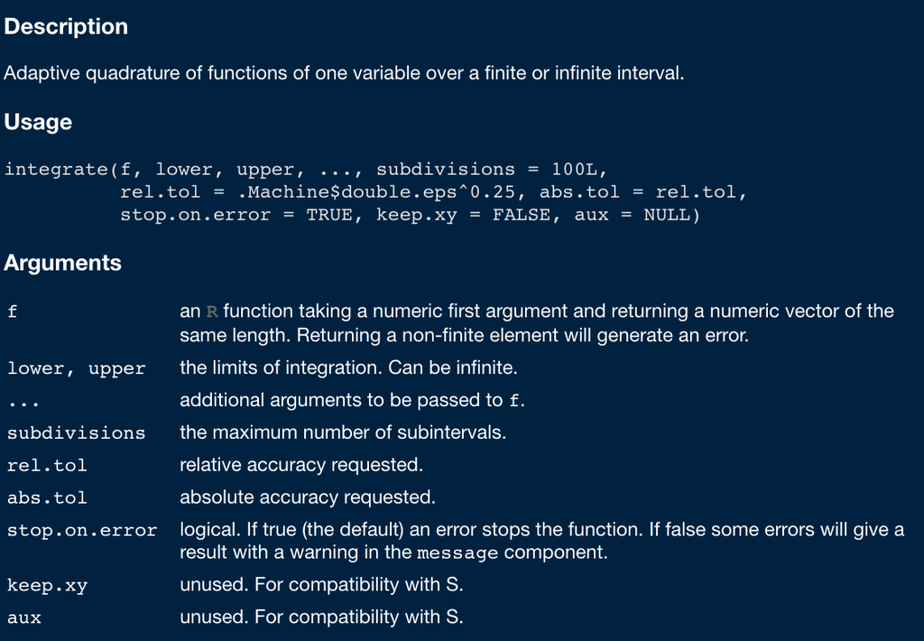

## Q1)

Based on the function given below

$$ f(x)=3x^5+4x^2+8x,\ 0<x<1 $$

Find an approximation to the integral I. Take n = 10000.

$$ I= \int_0^1 (3x^5+4x^2+8x)dx $$

```r
# Step 1: Define f(X)

f <- function(x) 3*x^5+4*x^2+8*x


# Step 2: Generate x1,...,xn  iid Uniform(min=a, max=b)

n=10^4
a <- 0; b <- 1

x <- runif(n= n, min= a, max= b)


# Step 3: Compute  (b-a)*g(Xbar)

g.Xbar = mean(sapply(x ,f))

estimate <-  (b-a)*g.Xbar

estimate
```

5.83892016866177

```r
# calculate real integral value
integrate(f, a, b)
```

```
5.833333 with absolute error < 6.5e-14
```

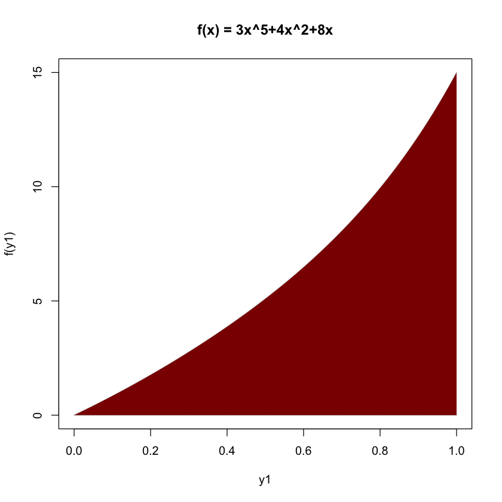

```r
y1 <- seq(a, b,0.001)
y.low1 <- rep(0,times = length(y1))

plot(y1, f(y1), type = "n", main = "f(x) = 3x^5+4x^2+8x", lwd = 2.5)

lines(y1,f(y.low1), col = 'grey')
lines(y1,f(y1), col = 'grey')

polygon(c(y1, rev(y1)), c(f(y1), rev(f(y.low1))), col = "darkred", border = NA)
```

## Q2)

Based on the function given below;

$$ f(x)= \frac{e^{-2x^3}}{4} + |x-6|,\ 0 \leq x \leq 12 $$

Compute the integral of;

$$ I = \int_0^{12} (\frac{e^{-2x^3}}{4} + |x-6|)dx $$

```r
# Step 1: Define f(X)

f <- function(x) exp(-2*x^3)/4 + abs(x-6)


# Step 2: Generate x1,...,xn  iid Uniform(min=a, max=b)

n=10^4
a <- 0; b <- 12

x <- runif(n= n, min= a, max= b)


# Step 3: Compute (b-a)*g(Xbar)

g.Xbar = mean(sapply(x ,f))

estimate <-  (b-a)*g.Xbar

estimate
```

36.2568615643501

```r
# calculate real integral value
integrate(f, a, b)
```

```
36.17719 with absolute error < 9.6e-05
```

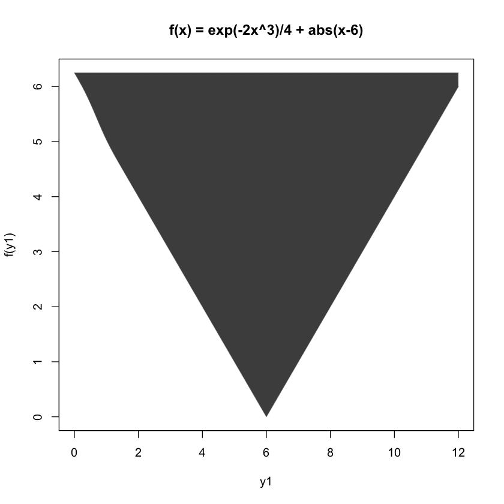

```r
y1 <- seq(a, b,0.001)
y.low1 <- rep(0,times = length(y1))

plot(y1, f(y1), type = "n", main = "f(x) = exp(-2x^3)/4 + abs(x-6)", lwd = 2.5)

lines(y1,f(y.low1), col = 'grey')
lines(y1,f(y1), col = 'grey')

polygon(c(y1, rev(y1)), c(f(y1), rev(f(y.low1))), col = "grey30", border = NA)
```

## Q3)

Based on the function given below;

$$ f(x)= \sqrt {x + \sqrt {x + \sqrt x } },\ 0 \leq x \leq 3 $$

Compute the integral of;

$$ I = \int_0^{3} \sqrt {x + \sqrt {x + \sqrt x } } dx $$

```r
# Step 1: Define f(X)

f <- function(x) sqrt(x + sqrt(x + sqrt(x)))


# Step 2: Generate x1,...,xn  iid Uniform(min=a, max=b)

n=10^4
a <- 0; b <- 3

x <- runif(n= n, min= a, max= b)


# Step 3: Compute (b-a)*g(Xbar)

g.Xbar = mean(sapply(x ,f))

estimate <-  (b-a)*g.Xbar

estimate
```

5.10790989055576

```r
# calculate real integral value
integrate(f, a, b)
```

```
5.111806 with absolute error < 2.7e-07
```

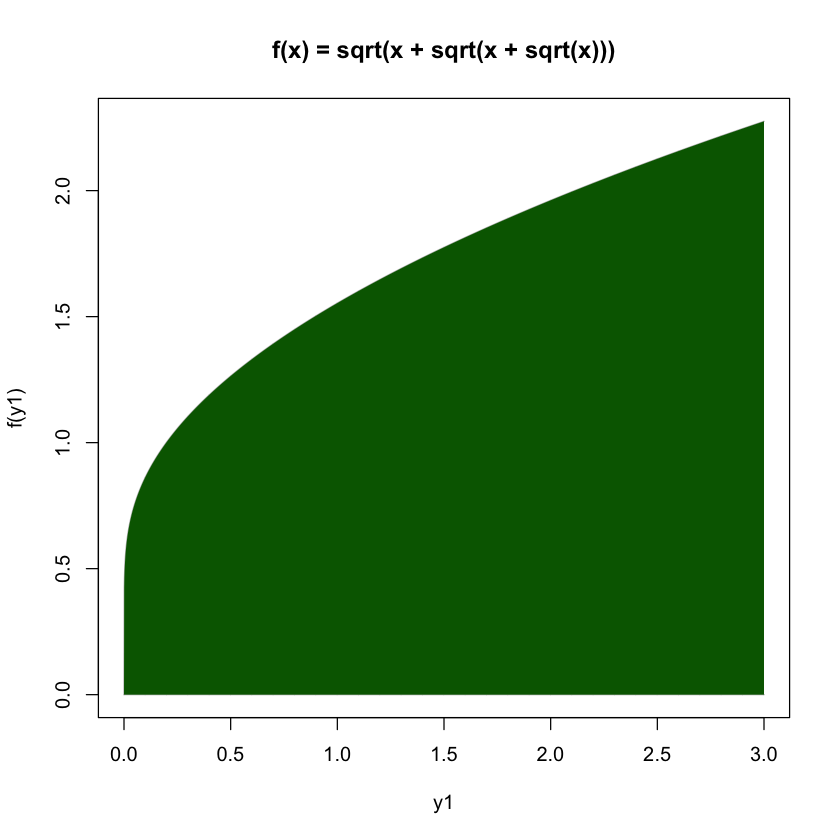

```r
y1 <- seq(a, b,0.001)
y.low1 <- rep(0,times = length(y1))

plot(y1, f(y1), type = "n", main = "f(x) = sqrt(x + sqrt(x + sqrt(x)))", lwd = 2.5)

lines(y1,f(y.low1), col = 'grey')
lines(y1,f(y1), col = 'grey')

polygon(c(y1, rev(y1)), c(f(y1), rev(f(y.low1))), col = "darkgreen", border = NA)
```

## Q4)

Find the area of the unit circle (with radius 1) by using Monte Carlo integration.

We know that we could find the area of unit circle by using following integral:

$$ I = 4\int_0^1 \sqrt {1-x^2}dx $$

```r
f <- function(x) 4*sqrt(1-x^2)
n <- 10^5
a <- 0; b <- 1
x <- runif(n,a,b)


estimate <- mean(sapply(x,f)) * (b-a)
estimate
```

3.1413029227557

```r
# calculate real integral value
integrate(f, a, b)
```

```
3.141593 with absolute error < 0.00016
```

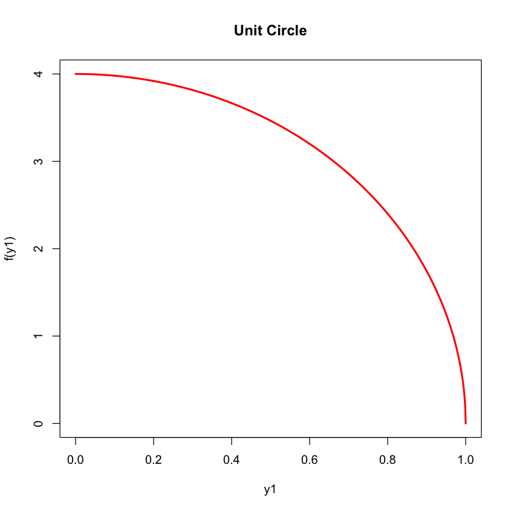

```r
y1 <- seq(a, b,0.001)
plot(y1, f(y1), type = "l",
main = "Unit Circle",
lwd = 2.5, col = "Red")
```

## Q5)

Based on the functions given below;

### a)

$$ f(x)= (cos(50x)+sin(20x))^2,\ 0 \leq x \leq 1 $$

Compute the integral of;

$$ I = \int_0^{1} (cos(50x)+sin(20x))^2 dx $$

```r
# Step 1: Define f(X)

f <- function(x) (cos(50*x)+sin(20*x))^2


# Step 2: Generate x1,...,xn  iid Uniform(min=a, max=b)

n=10^4
a <- 0; b <- 1

x <- runif(n= n, min= a, max= b)


# Step 3: Compute (b-a)*g(Xbar)

g.Xbar = mean(sapply(x ,f))

estimate <-  (b-a)*g.Xbar

estimate
```

0.965856313269564

```r
# calculate real integral value
integrate(f, a, b)
```

```
0.9652009 with absolute error < 1.9e-10
```

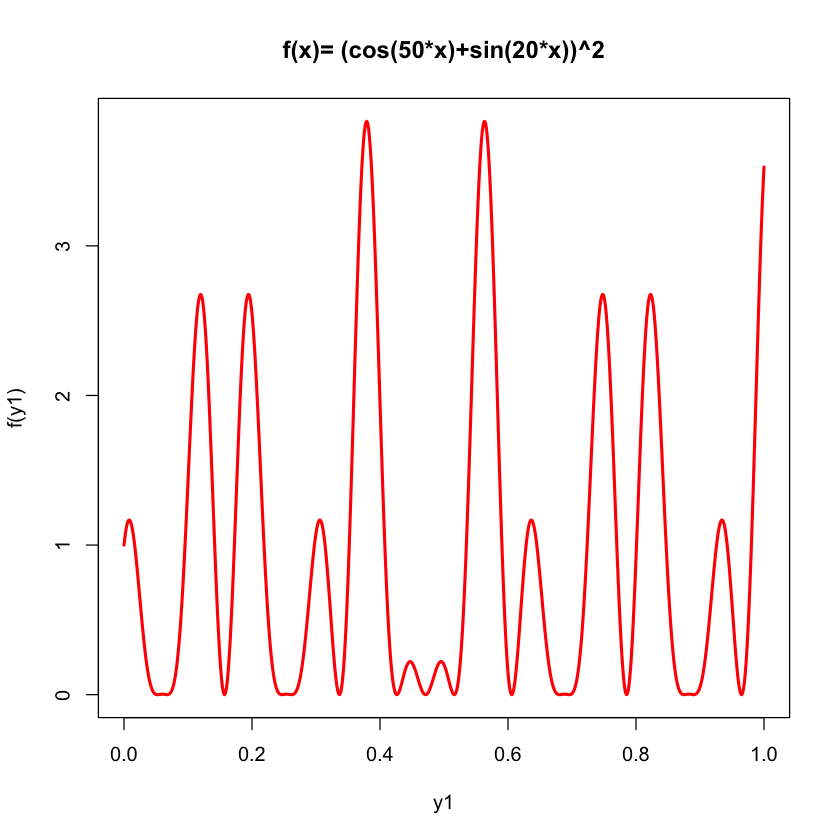

```r
y1<- seq(a,b,0.001)
plot(y1, f(y1), type="l", main="f(x)= (cos(50*x)+sin(20*x))^2", lwd=2.5, col="red")
```

### b) How do we simulate integral with infinit range??

$$ f(x)= (sin(x)-cos(x))^2,\ -\infty \leq x \leq \infty $$

where $X \sim N(0, 1)$

Compute the integral of;

$$ I = \int_{-\infty}^{\infty} ((sin(x)-cos(x))^2 dx $$

```r
# Step 1: Define f(X)

f <- function(x) (sin(x)-cos(x))^2


# Step 2: Generate x1,...,xn  iid Normal(n)

n=10^4
a <- -Inf; b <- Inf

x <- rnorm(n = n)


# Step 3: Compute g(Xbar)

g.Xbar = mean(sapply(x ,f))

estimate <-  g.Xbar

estimate
```

1.00871291564053

```r
integrand = function(x) (sin(x)-cos(x))^2*dnorm(x)

integrate(integrand,a,b)
```

```
1 with absolute error < 9.4e-05
```

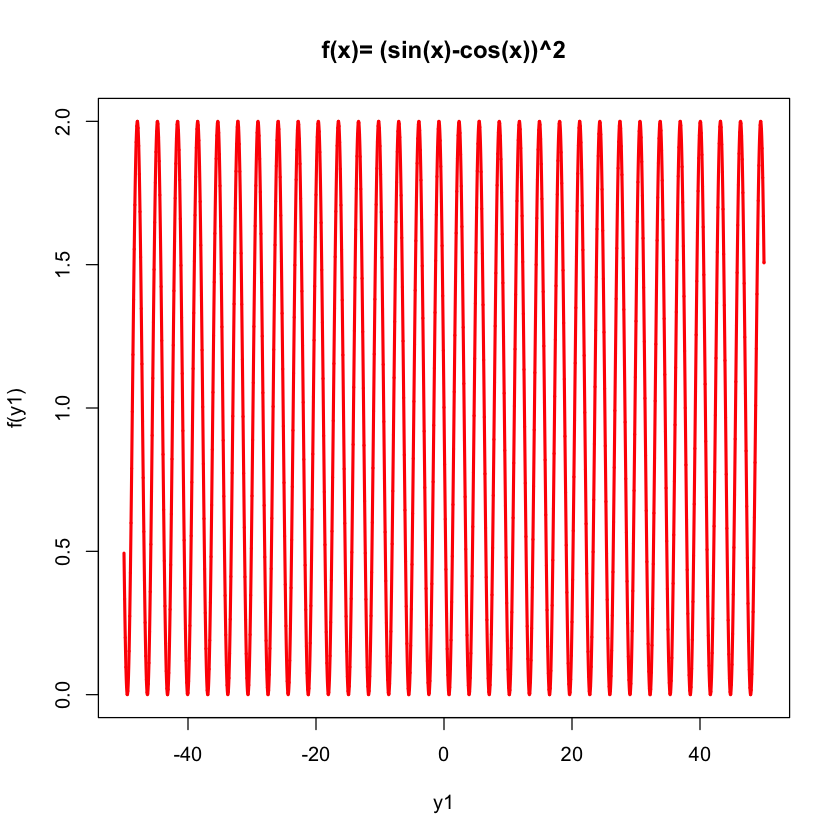

```r
y1<- seq(-50, 50, 0.001)
plot(y1, f(y1), type="l", main="f(x)= (sin(x)-cos(x))^2", lwd=2.5, col="red")
```

## Q6)

Based on the function given below;

$$ f(x) = e^{sin(x)} + x^5 + In(x^2),\ 0<x<\frac{\pi}{2} $$

Compute the integral of;

$$ I= \int_0^{\frac{\pi}{2}} e^{sin(x)} + x^5 + In(x^2) dx $$

Now, write an R function which calculates the Monte Carlo Integration for a given funtion and given upper and lower bounds of x.

```
estimate: 3.885552
integrate: 3.885093
```

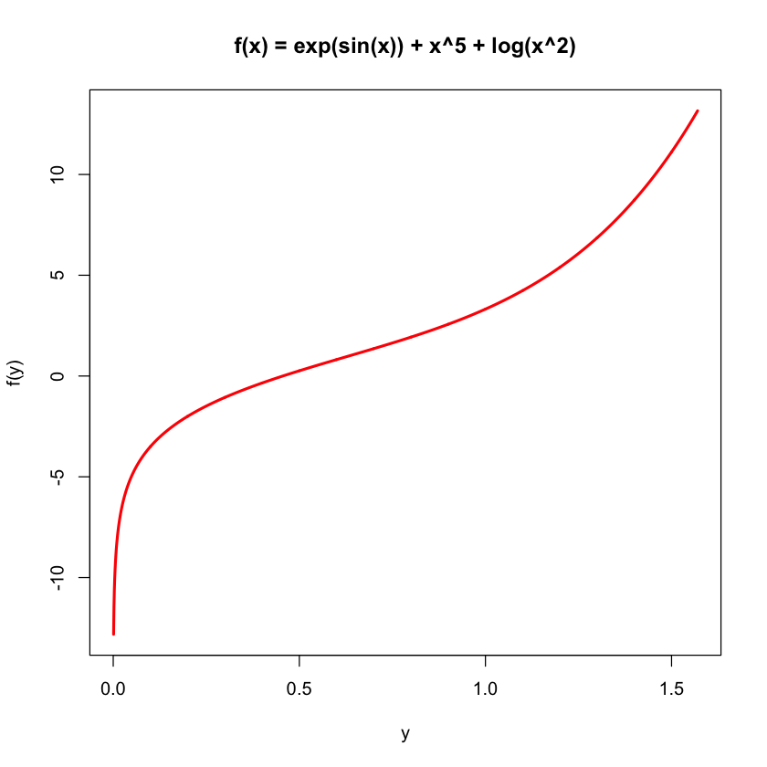

```r
monte.carlo <- function(upper, lower, f, n){

    set.seed(2022)

    # Step 1: Generate x1,...,xn  iid Uniform(min=a, max=b)

    x <- runif(n= n, min= lower, max= upper)


    # Step 2: Compute (b-a)*g(Xbar)

    g.Xbar = mean(sapply(x ,f))
    estimate <-  (upper-lower)*g.Xbar

    cat("estimate:", estimate, "\n")
    cat("integrate:", integrate(f,lower,upper)$value)


    y <- seq(lower, upper,0.001)
    plot(y, f(y), type = "l", main = "f(x) = exp(sin(x)) + x^5 + log(x^2)", lwd = 2.5, col = "Red")

}


f <- function(x) exp(sin(x)) + x^5 + log(x^2)
upper <- pi/2
lower <- 0
n <- 10^6

result <- monte.carlo(upper, lower, f, n)
```

# How can we use Monte Carlo Integration in Statistics?

## Q7)

Let X∼Exp(0.5) be an exponential random variable with rate =0.5. Approximate P(X>2) using Monte Carlo approximation and check your answer using "pexp".

We know that;

$$ f(x) = \frac{1}{\lambda}e^{\frac{-x}{\lambda}},\ x>0 $$

**How can we find P(x>2) ?**

$$ P(x>2) = \int_{2}^{\infty} \frac{1}{\lambda}e^{\frac{-x}{\lambda}}dx $$

In all question above we have g function which distributed as uniform(a, b). In hear, we do not have g function.

In such cases we can define an **indicator function** for g.

Let;

$$ g(x) = I_{(p,\infty)} = \begin{cases} 0 & \text{if }x\leq p\\ 1 & \text{if }x>p\\ \end{cases} $$

where p=2 given in the question

AND,

$$ \theta = P(X>p) = \int g(x)f(x)dx = E[g(x)] $$

This gives us;

$$ \int_{0}^2 0 * (\frac{1}{\lambda}e^{\frac{-x}{\lambda}})dx + \int_2^{\infty} 1 * (\frac{1}{\lambda}e^{\frac{-x}{\lambda}})dx $$

Thus our Monte Carlo approximation is given by;

```r
# Step 1: Define f(X)

f <- function(x) (1/lambda)*exp(-x/lambda)


# Step 2: Define g(X)

g <- function(x, p){
  if (x > p) return(1)
  else return(0)
}

# Step 3: Generate x1,...,xn  iid random variables from desired distribution

n=10^4
lambda <- 0.5
p <- 2


x <- rexp(n = n, rate = 0.5)


# Step 4: Compute the estimate

estimate = mean(sapply(x ,g, p))


estimate
```

0.3698

## $P(X>2) = 1- P(X \leq 2)$

```r
1- pexp(2, rate=lambda) #defining CDF
```

0.367879441171442

## Q8) FINDING NORMAL DISTRIBUTION CDF

Let $X \sim N(\mu,\sigma^2)$ and let p be a real number. Approximate the probability P(X<p) using Monte Carlo integration. Take, $\mu=5$, $\sigma=3$ and p=2.4.

We know that;

$$ f(x) = \frac{1}{\sqrt {2 \pi \sigma^2}}e^{\frac{(x- \mu)^2}{2\sigma^2}},\ -\infty<x<\infty $$

$$ P(x<p) = \int_{-\infty}^p \frac{1}{\sqrt {2 \pi \sigma^2}}e^{\frac{(x- \mu)^2}{2\sigma^2}}dx $$

In all question above we have g function which distributed as uniform(a, b). In hear, we do not have g function.

In such cases we can define an **indicator function** for g.

Let;

$$ g(x) = I_{(-\infty, p)} = \begin{cases} 1 & \text{if }x\leq p\\ 0 & \text{if }x>p\\ \end{cases} $$

AND,

$$ \theta = P(X<p) = \int g(x)f(x)dx = E[g(x)] $$

This gives us;

$$ \int_{-\infty}^p 1 * (\frac{1}{\sqrt {2 \pi \sigma^2}}e^{\frac{(x- \mu)^2}{2\sigma^2}})dx + \int_p^{\infty} 0 * (\frac{1}{\sqrt {2 \pi \sigma^2}}e^{\frac{(x- \mu)^2}{2\sigma^2}})dx $$

Thus our Monte Carlo approximation is given by;

$$ \hat \theta = g_m(\bar x) = \frac{1}{m} \sum_{i=1}^m I_{(x_i<p)} $$

```r
# Step 1: Define f(X)

f <- function(x) 1/(sqrt(2*pi*sigma^2)) * exp((-(x-mu)^2) / 2*sigma^2)


# Step 2: Define g(X)

g <- function(x, t){
  if (x < t) return(1)
  else return(0)
}

# Step 3: Generate x1,...,xn  iid random variables

n=10^4
mu <- 5
sigma <- 3
p <- 2.4


x <- rnorm(n = n, mean = mu, sd = sigma)


# Step 4: Compute the estimate

estimate = mean(sapply(x ,g, p))


estimate
```

0.2026

```r
pnorm(2.4, mean=mu, sd=sigma) #defining CDF
```

0.193062337141907

## Q9) FINDING GAMMA DISTRIBUTION CDF

Let $X \sim Gamma(\alpha,\beta)$ and let p be a real number. Approximate the probability P(X < p1)+P(x > p2) using Monte Carlo integration. Take, $\alpha=9$, $\beta=8$ and p1= 0.4 and p2=2. Besides, check your answer using "pgamma".

We know that;

$$ f(x) = \frac{1}{\Gamma (\alpha) \beta^\alpha}x^{(\alpha-1)} e^{\frac{-x}{\beta}},\ 0<x<\infty $$

$$ P(x<p) = \int_p^{\infty} \frac{1}{\Gamma (\alpha) \beta^\alpha}x^{(\alpha-1)} e^{\frac{-x}{\beta}}dx $$

In all question above we have g function which distributed as uniform(a, b). In hear, we do not have g function.

In such cases we can define an **indicator function** for g.

Let;

$$ g(x) = I_{(-\infty, p)} = \begin{cases} 1 & \text{if }x\leq p\\ 0 & \text{if }x>p\\ \end{cases} $$

AND,

$$ \theta = P(X<p) = \int g(x)f(x)dx = E[g(x)] $$

This gives us;

$$ \int_p^{\infty} 1* \frac{1}{\Gamma (\alpha) \beta^\alpha}x^{(\alpha -1)} e^{\frac{-x}{\beta}}dx + \int_p^{\infty} 0* \frac{1}{\Gamma (\alpha) \beta^\alpha}x^{(x-\alpha)} e^{\frac{-x}{\beta}}dx $$

Thus our Monte Carlo approximation is given by;

$$ \hat \theta = g_m(\bar x) = \frac{1}{m} \sum_{i=1}^m I_{(x_i<p)} $$

(Please Note that $\Gamma(t)= (t-1)!$)

```r
# Step 1: Define f(X)

f <- function(x) 1/(factorial(alpha-1)*beta^alpha)*x^(alpha-1)*exp(-x/beta)


# Step 2: Define g(X)

g1 <- function(x, p1){
  if (x < p1) return(1)
  else return(0)
}


g2 <- function(x, p2){
  if (x > p2) return(1)
  else return(0)
}

# Step 3: Generate x1,...,xn  iid random variables

n=10^5
alpha <- 9
beta <- 8
p1 <- 0.4
p2 <- 2

x <- rgamma(n = n, alpha, beta)


# Step 4: Compute the estimate

probability1 = mean(sapply(x ,g1, p1))
probability2 = mean(sapply(x ,g2, p2))

estimate = probability1 + probability2
cat("P(x < 0.4) + P(x > 2) =", estimate)
```

[output not shown]

```r
pgamma(0.4, alpha, beta) + (1-pgamma(2, alpha, beta)) #defining CDF
```

0.0277013916154789

## EXERCISE FROM THE BOOK

### Exercise 5.4 (page 150)

Write a function to compute a Monte Carlo estimate of the Beta(3, 3) cdf, and use the function to estimate F(x) for x = 0.1, 0.2, . . . , 0.9. Compare the estimates with the values returned by the **pbeta** function in R.

$$ f(x; \alpha, \beta)=\frac{\Gamma(\alpha +\beta)}{\Gamma(\alpha)+\Gamma(\beta)}x^{\alpha-1}(1-x)^{\beta-1}, 0 \leq x \leq 1 $$

CDF of Beta distribution;

$$ F(X) = P(X \leq x) = \int_0^x \frac{\Gamma(\alpha +\beta)}{\Gamma(\alpha)+\Gamma(\beta)}x^{\alpha-1}(1-x)^{\beta-1}, 0 \leq x \leq 1 $$

(Note that $\Gamma(t)= (t-1)!$)

We should define g function which should distribute uniform. Range of g function is equal to range of integral. Range of our integral is (0, x), so g~Uniform(0, x)

```r
set.seed(361)
n<- 10^4

beta_cdf <- function(x, alpha, beta){
    u <- runif(n, min=0, max=x)
    g = factorial(alpha+beta-1)/(factorial(alpha-1)*factorial(beta-1))*u^(alpha-1)*(1-u)^(beta-1)
    estimate= mean(x*g)
}

x= seq(0.1, 0.9, 0.1)

for(i in x){
    estimates=beta_cdf(i, 3,3)
    real_values = pbeta(i, 3,3)
    cat("x=", i, "\t", "estimates=", estimates, "\t", "real beta values=", real_values, "\n" )
}
```

```
x= 0.1 	 estimates= 0.008630343 	 real beta values= 0.00856
x= 0.2 	 estimates= 0.05783376 	 real beta values= 0.05792
x= 0.3 	 estimates= 0.1639318 	 real beta values= 0.16308
x= 0.4 	 estimates= 0.3190771 	 real beta values= 0.31744
x= 0.5 	 estimates= 0.4977538 	 real beta values= 0.5
x= 0.6 	 estimates= 0.6863473 	 real beta values= 0.68256
x= 0.7 	 estimates= 0.8389897 	 real beta values= 0.83692
x= 0.8 	 estimates= 0.9435028 	 real beta values= 0.94208
x= 0.9 	 estimates= 0.9852201 	 real beta values= 0.99144
```